# Making Sense of the Nonsensical: Analysis of Global Data on Suicide

Manon Le Bourgeois

```r
library(tidyverse)
library(kableExtra)
library(janitor)
#Import the Data
suicide_data <- read.csv("suicides.csv")
```

```r
# Data Cleaning
suicide_clean <- distinct(suicide_data)
suicide_clean <- clean_names(suicide_clean)

# There are some NA values in the HDI column which indicates the country's score in the Human Development Index for that year.

# There are some NA values in the HDI column which indicates the country's score in the Human Development Index for that year. However, since my question does not deal with that variable I can disregard it. It would be interesting to figure out if there is a pattern in the countries or years for which the HDI indicator is missing.

country_year <- suicide_clean %>%
  filter(year==1990|year==2000|year==2010)%>%
  select(country, year, gdp_per_capita) %>%
  unique()

country_year %>%
  group_by(country) %>%
  summarize(n_country=n()) %>%
  filter(n_country!=3)
```

```
## # A tibble: 36 × 2
##    country             n_country
##    <chr>                   <int>
##  1 Albania                     2
##  2 Antigua and Barbuda         2
##  3 Aruba                       2
##  4 Azerbaijan                  2
##  5 Bahamas                     2
##  6 Bahrain                     2
##  7 Croatia                     2
##  8 Cuba                        2
##  9 Cyprus                      2
## 10 Denmark                     2
## # … with 26 more rows
```

```r
countries <- country_year %>%
  group_by(country) %>%
  summarize(n_country=n()) %>%
  filter(n_country==3)

country_year %>%
  select(country) %>%
  unique()
```

```
##                           country
## 1                         Albania
## 25            Antigua and Barbuda
## 49                      Argentina
## 85                        Armenia
## 121                         Aruba
## 145                     Australia
## 181                       Austria
## 217                    Azerbaijan
## 241                       Bahamas
## 265                       Bahrain
## 289                      Barbados
## 325                       Belarus
## 361                       Belgium
## 397                        Belize
```

[output cut: 81 more lines]

```r
suicide_final <- suicide_clean %>%
  filter(country%in%countries$country)

# ANALYSIS: I am only looking at countries for which I have data in 1990, 2000, and 2010. The only African/Middle-Eastern country is Mauritius and Israel. Few Asian countries are included, except for Japan, South Korea, Singapore, and Thailand. Most countries included in the data set are Western and Eastern European, Commonwealth countries, Latin American, and Central Asia.
```

```r
# Creating variables for analysis

# Create a variable that is the total number of suicides per 100, 000 inhabitants (across demographic categories) for each country, for each year:
total_suicide_rate <- suicide_final %>%
  group_by(country,year) %>%
  summarize(total_suicide_rate = sum(suicides_100k_pop))
# Create a variable that is the number of suicides per 100, 000 inhabitants by sex for each country, for each year:
sex_suicide_rate <- suicide_final %>%
  group_by(country,year,sex) %>%
  summarize(sex_suicide_rate = sum(suicides_100k_pop))
suicide_final <-left_join(suicide_final, total_suicide_rate, by=c("country", "year"))
suicide_final <-left_join(suicide_final, sex_suicide_rate, by=c("country","year", "sex"))
```

```r
# Summary Statistics

# Summary Statistics for suicide and GDP across countries for the 3 years observed:
SumStat_table <-suicide_final %>%
  filter(year=="1990" | year=="2000"|year=="2010")%>%
  group_by(year) %>%
  summarize(suicide_mean=mean(total_suicide_rate), suicide_med=median(total_suicide_rate), suicide_min=min(total_suicide_rate), suicide_max=max(total_suicide_rate),
            gdp_mean=mean(gdp_per_capita), gdp_median=median(gdp_per_capita), gdp_min=min(gdp_per_capita), gdp_max=max(gdp_per_capita))

# Summary Statistics for suicide across countries by sex for the 3 years observed:
SumStat_sex_table <-suicide_final %>%
  filter(year=="1990" | year=="2000"|year=="2010")%>%
  group_by(year,sex) %>%
  summarize(suicide_sex_mean=mean(sex_suicide_rate), suicide_sex_med=median(sex_suicide_rate), suicide_sex_min=min(sex_suicide_rate), suicide_sex_max=max(sex_suicide_rate))
```

[output not shown]

# **Introduction**

Globally, more than 700,000 people die each year by suicide. That is one person every 40 seconds. While data cannot explain or even capture the stories and the motives behind each of these deaths, data analysis can help reveal some patterns in and determinants of suicide deaths. In this analysis, I will focus on exploring the relationship between economic development and suicide rates and how this relationship may vary by sex. To measure economic development, I will be using GDP per capita, while suicide rates will be measured by the number of suicide deaths per 100, 000 inhabitants. I will be using a compiled dataset that gathers data on suicides, demographics, and development by country between 1985 and 2016. GDP data comes from the World Bank while data on suicide deaths comes from the World Health Organization. My analysis will focus on the years 1990, 2000, and 2010, and thus will only include those countries for which the data is available for each of these years.

Psychiatric disorder being a leading cause of suicide and environmental stress increasing the probability of developing a mental illness, I hypothesize that suicide rates will be lower in countries with higher GDP per capita and that male suicide rates will be more negatively correlated with GDP per capita than female suicide rates (Bachmann, 2018; Herbert, 1997). The intuition behind my hypothesis is that poorer countries may provide a more stressful environment to their population because of financial scarcity. And that males, when they evolve in patriarchal societies where they have traditionally been assigned the role of the “breadwinner”, may experience this financial stress more intensely, increasing their propensity to commit suicide relative to females.

# Overview of the Data Set

```r
SumStat_table %>%
  kbl(col.names=c("Year", "Mean Number of Suicides", "Median Number of Suicides", "Minimum Number of Suicides", "Maximum Number of Suicides","Mean GDP per capita", "Median GDP per capita", "Minimum GDP per capita", "Maximum GDP per capita"), digits=2, caption= "Table 1. Summary Statistics for Suicides per 100, 000 Inhabitants and GDP per Capita for the Years 1990, 2000, 2010") %>%
  kable_styling()
```

Table 1. Summary Statistics for Suicides per 100, 000 Inhabitants and GDP per Capita for the Years 1990, 2000, 2010

| Year | Mean Number of Suicides | Median Number of Suicides | Minimum Number of Suicides | Maximum Number of Suicides | Mean GDP per capita | Median GDP per capita | Minimum GDP per capita | Maximum GDP per capita |
| --- | --- | --- | --- | --- | --- | --- | --- | --- |
| 1990 | 163.31 | 163.18 | 1.32 | 399.17 | 10323.47 | 4168 | 715 | 36871 |
| 2000 | 160.90 | 142.36 | 1.16 | 504.47 | 13346.15 | 7483 | 313 | 51841 |
| 2010 | 140.51 | 129.23 | 1.16 | 518.20 | 25265.00 | 13874 | 991 | 111328 |

Table 1 gives the cross-country mean, median, minimum, and maximum values of suicide deaths per 100, 000 inhabitants and GDP per capita in 1990, 2000, and 2010. There is a lot of variation in both the number of suicide deaths and the value of GDP per capita in the data set. Additionally, the difference between the value of the mean GDP per capita and that of the median suggests that some countries with particularly high gross domestic products per capita may be driving up the mean. This, however, should not impact the significance of the results.

```r
SumStat_sex_table %>%
kbl(col.names=c("Year", "Sex", "Mean Number of Suicides", "Median Number of Suicides", "Minimum Number of Suicides","Maximum Number of Suicides"), digits=2, caption= "Table 2. Summary Statistics on Suicides per 100,000 Inhabitants by Sex for the Years 1990, 2000, 2010") %>%
  kable_styling()
```

Table 2. Summary Statistics on Suicides per 100,000 Inhabitants by Sex for the Years 1990, 2000, 2010

| Year | Sex | Mean Number of Suicides | Median Number of Suicides | Minimum Number of Suicides | Maximum Number of Suicides |
| --- | --- | --- | --- | --- | --- |
| 1990 | female | 37.65 | 30.45 | 0.00 | 118.25 |
| 1990 | male | 125.66 | 111.54 | 1.32 | 326.28 |
| 2000 | female | 31.95 | 28.10 | 0.00 | 81.86 |
| 2000 | male | 128.95 | 113.24 | 1.16 | 424.93 |
| 2010 | female | 28.68 | 24.28 | 0.00 | 158.52 |
| 2010 | male | 111.83 | 95.38 | 1.16 | 359.68 |

# **Results**

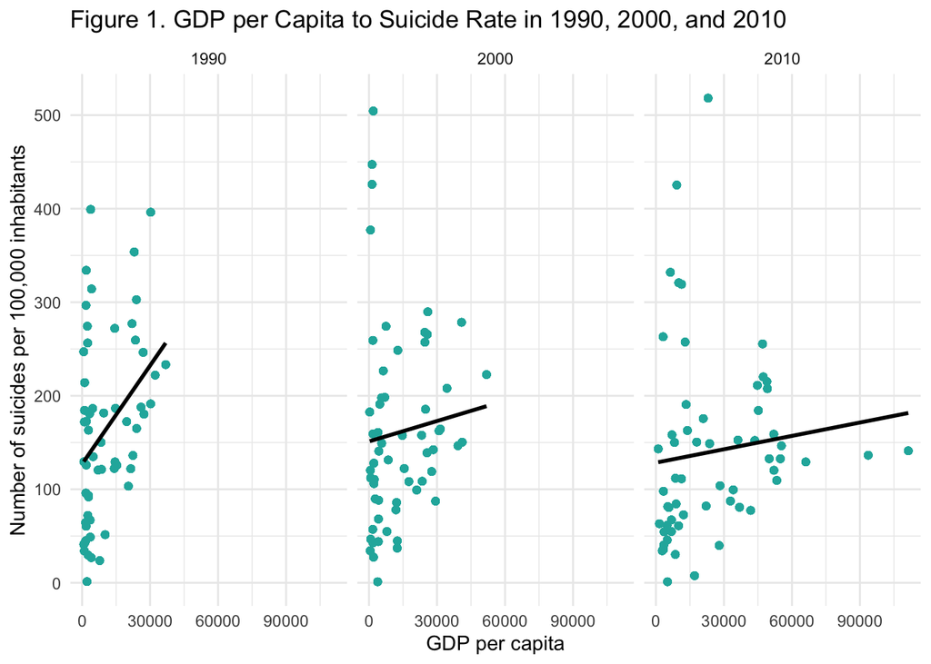

```r
suicide_final %>%
  filter(year==1990|year==2000|year==2010) %>%
  group_by(country) %>%
ggplot(aes(x=gdp_per_capita,y=total_suicide_rate))+
  geom_point(color="lightseagreen")+
  geom_smooth(method="lm", se=FALSE, color="black")+
  xlab("GDP per capita")+
  ylab("Number of suicides per 100,000 inhabitants")+
  ggtitle("Figure 1. GDP per Capita to Suicide Rate in 1990, 2000, and 2010")+
  facet_grid(.~year) +
  theme_minimal()
```

Figure 1 plots countries’ GDP per capita against the number of suicides per 100, 000 inhabitants in 1990, 2000, and 2010, all demographic categories combined. I observe a positive relationship between GDP per capita and the suicide rate for each year, meaning that as GDP per capita increases, so does the total number of suicide deaths per 100,000 inhabitants. Interestingly, the relationship becomes less and less positive over the years, as observed by the flattening out of the line of best fit.

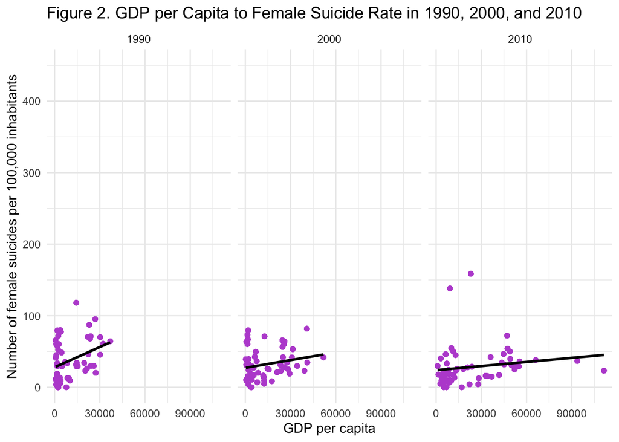

```r
suicide_final %>%
  filter(year==1990|year==2000|year==2010, sex=="female") %>%
  group_by(country,sex) %>%
ggplot(aes(x=gdp_per_capita,y=sex_suicide_rate))+
  geom_point(color="mediumorchid")+
  geom_smooth(method="lm", se=FALSE, color="black")+
  expand_limits(y=c(0,450))+
  xlab("GDP per capita")+
  ylab("Number of female suicides per 100,000 inhabitants")+
  ggtitle("Figure 2. GDP per Capita to Female Suicide Rate in 1990, 2000, and 2010")+
  facet_grid(.~year)+
  theme_minimal()
```

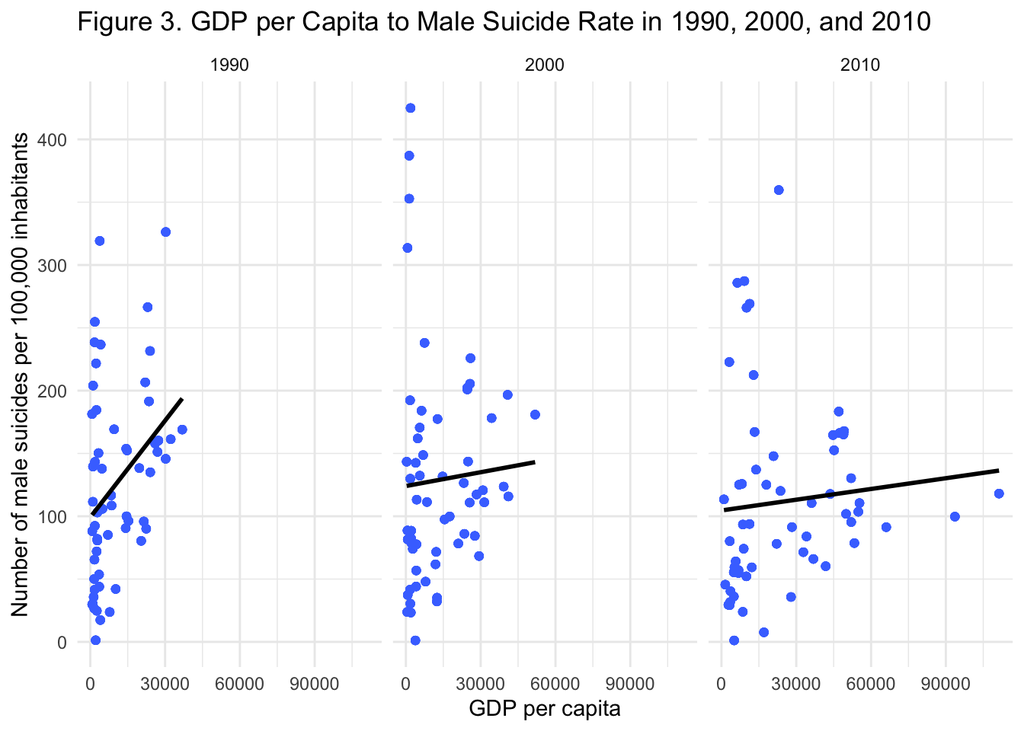

```r
suicide_final %>%
  filter(year==1990|year==2000|year==2010, sex=="male") %>%
  group_by(country,sex) %>%
ggplot(aes(x=gdp_per_capita,y=sex_suicide_rate))+
  geom_point(color="royalblue1")+
  geom_smooth(method="lm", se=FALSE, color="black")+
  xlab("GDP per capita")+
  ylab("Number of male suicides per 100,000 inhabitants")+
  ggtitle("Figure 3. GDP per Capita to Male Suicide Rate in 1990, 2000, and 2010")+
  facet_grid(.~year)+
  theme_minimal()
```

Figure 2 plots countries’ GDP per capita against the number of female suicides per 100, 000 inhabitants in 1990, 2000, and 2010. Figure 3 does the same for male suicides. For both sexes, there is a positive relationship between GDP per capita and the sex-specific suicide rate, however, the strength of that relationship varies between sexes over time. Indeed, the relationship between GDP per capita and the suicide rate is much more positive for males than for females in 1990 and slightly more positive in 2000 and 2010. That is, for all three years studied, the line of best fit for males (Fig. 3) is steeper than the line of best fit for females (Fig. 2).

# **Discussion**

The findings only partially support my hypothesis. Instead of observing a negative correlation between GDP per capita and suicide rate, I find a positive relationship between the two variables throughout the years studied. However, I do find that the relationship is stronger for males than it is for females, although not in the direction I had predicted.

Because there are many uncontrolled confounding variables in this study, I cannot make a causal claim about the relationship between GDP per capita and suicide rate. However, the results do reveal important patterns. First, they suggest that richer countries have higher suicide rates and second, they indicate that predictors of suicide may vary by sex. Future research should focus on explaining the socioeconomic mechanisms creating the patterns this analysis has brought forth and should work to identify the specific characteristics of richer nations that sustain higher suicide rates. Future research should also give special attention to how these characteristics may differ by sex or how they may affect males and females differently. Some traits to explore could be access to firearms, religiosity, social isolation, occupational stress, and income inequality. Robustly identifying these traits and how they vary between sexes will allow governments and communities to make changes to adequately support those most at risk.

Finally, these findings cannot be understood as reflecting truly global patterns as the data set excludes half of the world’s countries. Further, out of the 95 countries present in the data set, only 59 have data for all three years studied. As such only about a third of the world’s countries are included in this analysis. The countries represented in this subset are not equally distributed throughout the globe, in fact, Israel and Mauritius are the only Middle-Eastern and African countries included in the data set. With Africa being home to many of the poorest countries in the world, this analysis essentially fails to capture the relationship between GDP per capita and suicide rates in the world’s poorest countries. Additionally, China and India, which together account for more than a third of the world population today, are missing. As such, this study will serve as an initial analysis of global patterns between GDP and suicide rates, but further research should be done with a more complete data set.

# **References**

Bachmann, S. (2018). Epidemiology of Suicide and the Psychiatric Perspective. International Journal of Environmental Research and Public Health, 15(7), 1425. https://doi.org/10.3390/ijerph15071425

Herbert, J. (1997). Fortnightly review: Stress, the brain, and mental illness. BMJ, 315(7107), 530–535. https://doi.org/10.1136/bmj.315.7107.530

Rusty. (2019). Suicide Rates Overview 1985 to 2016. Kaggle. https://www.kaggle.com/datasets/russellyates88/suicide-rates-overview-1985-to-2016